# Team 7: Spotify Songs Analysis

Team Members: Sarva Praneeth, Lakshmi Sashrika Pathuri, Aravinda Vijayaram Kumar

2023-12-16

# **Introduction**

In the expansive and dynamic realm of music streaming platforms, exploring the characteristics of songs opens up opportunities for profound insights that can transform user experiences. Within the extensive array of tracks available on platforms like Spotify, the ability to identify patterns and connections among diverse audio attributes holds tremendous potential. This analysis sets out on a voyage through the intricate landscape of audio features, encompassing various genres, with the objective of predicting song popularity, crafting personalized playlists, and enriching overall user satisfaction.

In our quest, we will dive into the detailed elements of songs, employing robust machine learning models such as k-Nearest Neighbors (KNN), Random Forest, XGBoost, and others. By scrutinizing the distributions of audio features and revealing correlations between them, our aim is to unravel the inherent patterns that define genres and captivate audiences. These models not only hold the capability to predict a song’s genre but also offer a nuanced comprehension of how diverse audio attributes contribute to its allure.

Moreover, our exploration extends into the realm of danceability, a fundamental aspect of music that often transcends genre boundaries. To grasp the influence of different features on danceability, we utilize methodologies such as Principal Component Analysis (PCA) and regression analysis. These techniques enable us to distill the essential components that shape a song’s danceability, providing insights into the intricate interplay of harmonies, rhythms, and melodies.

As we embark on this analytical journey, our goal is to uncover the concealed intricacies within the fabric of musical compositions. By decoding the complex relationships between audio features, genres, and danceability, we strive to offer not just predictive insights but also a heightened appreciation for the artistry that defines our diverse and constantly evolving musical landscape.

# **Dataset**

The real-time dataset same as the one used in midterm, encompasses a comprehensive collection of 42,305 rows, merging information from Spotify’s vast music library. The dataset presents a rich assortment of information, combining various audio features and metadata related to diverse musical tracks, offering a nuanced perspective on the intricate characteristics of contemporary music.

The dataset comprises an array of audio features, including danceability, energy, key, loudness, mode, speechiness, acousticness, instrumentalness, liveness, valence, tempo, and time signature. These features provide valuable insights into the nuanced musical compositions and inherent attributes of each track, enabling a deeper understanding of the multifaceted nature of musical expression and creativity.

Additionally, the dataset incorporates a range of unique identifiers, such as type, id, URI, track_href, and analysis_url, facilitating seamless linkage and retrieval of supplementary information associated with each track. This interconnected system offers an expansive view of the diverse musical landscape, highlighting the interconnected nature of contemporary music production and distribution.

Furthermore, the dataset includes critical information on the duration of each track, meticulously measured in milliseconds, and encompasses genre classifications, specific song names, and titles of individual tracks. This comprehensive dataset serves as a valuable resource for conducting in-depth analyses and uncovering intricate patterns and trends within the dynamic realm of music composition and production.

**Key Columns**:

*Danceability*: Signifies the track’s suitability for dancing, incorporating a blend of musical elements to gauge its rhythmic and dance-friendly nature.

*Energy*: Represents the song’s intensity and activity level, encapsulating features such as tempo, volume, and rhythmic strength to define the overall dynamism and liveliness of the music.

*Key*: Reflects the musical key of the track, determining the pitch and tonality of the music and contributing to the overall melodic structure and tonal composition. Loudness: Indicates the overall volume or amplitude of the song, measured in decibels (dB), offering insights into the track’s auditory presence and sonic impact.

*Mode*: Represents the modality (major or minor) of a track, delineating the type of scale used in the track’s melodic construction and serving as a foundational element in defining the music’s emotional tone and tonal texture.

*Speechiness*: Indicates the presence of spoken words in the song, helping to distinguish between instrumental and vocal-centric compositions.

*Acousticnes*s: Represents the presence of acoustic elements in the song, with high values suggesting a stronger presence of acoustic sounds.

*Instrumentalness*: Reflects the probability of a track being instrumental, with higher values indicating a higher likelihood of the absence of vocals.

*Liveness*: Indicates the likelihood of a track being recorded live, highlighting the presence of an audience or live recording ambiance.

*Valence*: Represents the overall mood and emotional character of a track, typically denoting the positivity or happiness conveyed by the music.

*Tempo*: Indicates the speed or pace of a track, typically measured in beats per minute (BPM), defining the overall rhythm and pacing of the music.

*Duration_ms*: Represents the duration of the track in milliseconds, providing insights into the length and temporal structure of the music.

*Genre*: Indicates the genre or category to which the song belongs, defining its stylistic and thematic classification within the broader spectrum of music.

*Song_name*: Refers to the name or title of the individual song, serving as a distinctive identifier for each musical composition.

*Title*: Represents the title of the track or the name of the musical composition, providing a unique identifier for cataloging and organizational purposes.

*Time_Signature*: Indicates the notational convention specifying the number of beats in each bar or measure, providing insights into the rhythmic structure and temporal organization of the music.

These key columns collectively contribute to a comprehensive understanding of the musical attributes, thematic characteristics, and genre-specific classifications within the Spotify dataset.

There are certain limitations as well in the dataset.The dataset from Spotify provides valuable insights into music characteristics and genre trends, yet it comes with certain limitations that warrant attention. One primary concern revolves around potential biases in the sampled data, which might not fully represent the rich diversity of musical genres and styles. Moreover, the dataset’s static nature could restrict a comprehensive understanding of dynamic shifts in music trends over time. Additionally, the absence of detailed metadata and potential data quality issues, such as missing or inaccurate values, pose challenges to the reliability and robustness of any analytical inferences drawn from the dataset. It is imperative to acknowledge these limitations to ensure a balanced and nuanced interpretation of the dataset’s findings within the broader context of music analysis and industry insights.

Source of dataset: This research project’s dataset (Dataset of songs in Spotify)was obtained via Kaggle, a recognized site for sharing and accessing datasets.**[1]**

# **Exploratory Data Analysis**

In the scholarly realm of data analysis, Exploratory Data Analysis (EDA) stands as a pivotal phase, akin to the preliminary investigations conducted by a seasoned researcher before embarking on a comprehensive study. Picture this phase as the initial survey of an unexplored scientific landscape, where the analyst endeavors to unearth latent patterns, identify anomalies, test hypotheses, and validate assumptions through a meticulous examination of summary statistics and graphical representations.

Exploratory Data Analysis(EDA) refers to the critical process of performing initial investigations on data so as to discover patterns,to spot anomalies,to test hypothesis and to check assumptions with the help of summary statistics and graphical representations.**[2]**

The main purpose of EDA is to help look at data before making any assumptions. It can help identify obvious errors, as well as better understand patterns within the data, detect outliers or anomalous events, find interesting relations among the variables.**[3]**

Graphical representations, the visual lexicon of academia, play a crucial role in this narrative. Histograms, scatter plots, and box plots are akin to visual arguments, illustrating relationships between variables and conveying complex concepts with clarity. These visual aids not only facilitate the analyst’s understanding but also serve as communicative tools in scholarly discourse.

Moreover, EDA validates assumptions, a process analogous to literature review and theoretical grounding in academic research. It ensures that the initial assumptions made about the dataset withstand scholarly scrutiny, providing a robust foundation for subsequent analyses.

Loading the dataset-

```r
#Loading the dataset
library(readr)
dataset <- read.csv("genres_v2.csv")
print(str(dataset))
```

```
## 'data.frame':    42305 obs. of  22 variables:
##  $ danceability    : num  0.831 0.719 0.85 0.476 0.798 0.721 0.718 0.694 0.774 0.893 ...
##  $ energy          : num  0.814 0.493 0.893 0.781 0.624 0.568 0.668 0.711 0.751 0.907 ...
##  $ key             : int  2 8 5 0 2 0 8 8 1 11 ...
##  $ loudness        : num  -7.36 -7.23 -4.78 -4.71 -7.67 ...
##  $ mode            : int  1 1 1 1 1 1 1 1 1 1 ...
##  $ speechiness     : num  0.42 0.0794 0.0623 0.103 0.293 0.414 0.137 0.221 0.198 0.367 ...
##  $ acousticness    : num  0.0598 0.401 0.0138 0.0237 0.217 0.0452 0.0254 0.0397 0.0614 0.152 ...
##  $ instrumentalness: num  1.34e-02 0.00 4.14e-06 0.00 0.00 2.12e-01 7.80e-03 0.00 0.00 3.11e-02 ...
##  $ liveness        : num  0.0556 0.118 0.372 0.114 0.166 0.128 0.124 0.112 0.0728 0.558 ...
##  $ valence         : num  0.389 0.124 0.0391 0.175 0.591 0.109 0.038 0.283 0.189 0.302 ...
##  $ tempo           : num  157 115 218 187 148 ...
##  $ type            : chr  "audio_features" "audio_features" "audio_features" "audio_features" ...
##  $ id              : chr  "2Vc6NJ9PW9gD9q343XFRKx" "7pgJBLVz5VmnL7uGHmRj6p" "0vSWgAlfpye0WCGeNmuNhy" "0VSXnJqQkwuH2ei1nOQ1nu" ...
##  $ uri             : chr  "spotify:track:2Vc6NJ9PW9gD9q343XFRKx" "spotify:track:7pgJBLVz5VmnL7uGHmRj6p" "spotify:track:0vSWgAlfpye0WCGeNmuNhy" "spotify:track:0VSXnJqQkwuH2ei1nOQ1nu" ...
##  $ track_href      : chr  "https://api.spotify.com/v1/tracks/2Vc6NJ9PW9gD9q343XFRKx" "https://api.spotify.com/v1/tracks/7pgJBLVz5VmnL7uGHmRj6p" "https://api.spotify.com/v1/tracks/0vSWgAlfpye0WCGeNmuNhy" "https://api.spotify.com/v1/tracks/0VSXnJqQkwuH2ei1nOQ1nu" ...
##  $ analysis_url    : chr  "https://api.spotify.com/v1/audio-analysis/2Vc6NJ9PW9gD9q343XFRKx" "https://api.spotify.com/v1/audio-analysis/7pgJBLVz5VmnL7uGHmRj6p" "https://api.spotify.com/v1/audio-analysis/0vSWgAlfpye0WCGeNmuNhy" "https://api.spotify.com/v1/audio-analysis/0VSXnJqQkwuH2ei1nOQ1nu" ...
##  $ duration_ms     : int  124539 224427 98821 123661 123298 112511 77584 127524 140326 121979 ...
##  $ time_signature  : int  4 4 4 3 4 4 4 3 4 4 ...
##  $ genre           : chr  "Dark Trap" "Dark Trap" "Dark Trap" "Dark Trap" ...
##  $ song_name       : chr  "Mercury: Retrograde" "Pathology" "Symbiote" "ProductOfDrugs (Prod. The Virus and Antidote)" ...
##  $ Unnamed..0      : num  NA NA NA NA NA NA NA NA NA NA ...
##  $ title           : chr  "" "" "" "" ...
## NULL
```

Dropping `Unnnamed..0` column-

```r
dataset_na <- subset(dataset,select = -c(Unnamed..0,title, uri, track_href, id, analysis_url, song_name))
print(colnames(dataset_na))
```

```
##  [1] "danceability"     "energy"           "key"              "loudness"
##  [5] "mode"             "speechiness"      "acousticness"     "instrumentalness"
##  [9] "liveness"         "valence"          "tempo"            "type"
## [13] "duration_ms"      "time_signature"   "genre"
```

Checking if we have any NA values in any of the coloumns-

```r
null_counts <- colSums(is.na(dataset_na))
print(null_counts)
```

```
##     danceability           energy              key         loudness
##                0                0                0                0
##             mode      speechiness     acousticness instrumentalness
##                0                0                0                0
##         liveness          valence            tempo             type
##                0                0                0                0
##      duration_ms   time_signature            genre
##                0                0                0
```

Filling of there any blank values with NA values-

```r
dataset_na[dataset_na == " "] <- NA
null_counts1 <- colSums(is.na(dataset_na))
print(null_counts1)
```

```
##     danceability           energy              key         loudness
##                0                0                0                0
##             mode      speechiness     acousticness instrumentalness
##                0                0                0                0
##         liveness          valence            tempo             type
##                0                0                0                0
##      duration_ms   time_signature            genre
##                0                0                0
```

Obtaining and displaying the summary of the dataset

```r
# Summary of the dataset
summary(dataset)
```

```
##   danceability        energy              key           loudness
##  Min.   :0.0651   Min.   :0.000243   Min.   : 0.00   Min.   :-33.357
##  1st Qu.:0.5240   1st Qu.:0.632000   1st Qu.: 1.00   1st Qu.: -8.161
##  Median :0.6460   Median :0.803000   Median : 6.00   Median : -6.234
##  Mean   :0.6394   Mean   :0.762516   Mean   : 5.37   Mean   : -6.465
##  3rd Qu.:0.7660   3rd Qu.:0.923000   3rd Qu.: 9.00   3rd Qu.: -4.513
##  Max.   :0.9880   Max.   :1.000000   Max.   :11.00   Max.   :  3.148
##
##       mode         speechiness      acousticness       instrumentalness
##  Min.   :0.0000   Min.   :0.0227   Min.   :0.0000011   Min.   :0.00000
##  1st Qu.:0.0000   1st Qu.:0.0491   1st Qu.:0.0017300   1st Qu.:0.00000
##  Median :1.0000   Median :0.0755   Median :0.0164000   Median :0.00594
##  Mean   :0.5495   Mean   :0.1366   Mean   :0.0961605   Mean   :0.28305
##  3rd Qu.:1.0000   3rd Qu.:0.1930   3rd Qu.:0.1070000   3rd Qu.:0.72200
##  Max.   :1.0000   Max.   :0.9460   Max.   :0.9880000   Max.   :0.98900
##
##     liveness         valence           tempo            type
##  Min.   :0.0107   Min.   :0.0187   Min.   : 57.97   Length:42305
##  1st Qu.:0.0996   1st Qu.:0.1610   1st Qu.:129.93   Class :character
##  Median :0.1350   Median :0.3220   Median :144.97   Mode  :character
##  Mean   :0.2141   Mean   :0.3571   Mean   :147.47
##  3rd Qu.:0.2940   3rd Qu.:0.5220   3rd Qu.:161.46
##  Max.   :0.9880   Max.   :0.9880   Max.   :220.29
##
##       id                uri             track_href        analysis_url
##  Length:42305       Length:42305       Length:42305       Length:42305
##  Class :character   Class :character   Class :character   Class :character
##  Mode  :character   Mode  :character   Mode  :character   Mode  :character
##
##
##
##
##   duration_ms     time_signature     genre            song_name
##  Min.   : 25600   Min.   :1.000   Length:42305       Length:42305
##  1st Qu.:179840   1st Qu.:4.000   Class :character   Class :character
##  Median :224760   Median :4.000   Mode  :character   Mode  :character
##  Mean   :250866   Mean   :3.973
##  3rd Qu.:301133   3rd Qu.:4.000
##  Max.   :913052   Max.   :5.000
##
##    Unnamed..0       title
##  Min.   :    0   Length:42305
##  1st Qu.: 5256   Class :character
##  Median :10480   Mode  :character
##  Mean   :10484
##  3rd Qu.:15709
##  Max.   :20999
##  NA's   :21525
```

In the initial stage of data preparation, we conducted a thorough check to identify any missing values in the dataset across various columns. Following this, we proceeded to address any empty or blank entries by appropriately filling them with NA values for further clarity and consistency. This preprocessing step enabled us to ensure the integrity and completeness of the dataset, providing a reliable foundation for subsequent data analysis and visualization. With these essential data handling procedures completed, we were well-equipped to proceed with the visualization and exploration of the dataset to glean valuable insights and patterns.

### **Visulaization of Data**

Data visualization is an important component of Exploratory Data Analysis (EDA) because it allows a data analyst to “look at” their data and get to know the variables and relationships between them.**[4]**

Previously in our midterm we focussed our EDA on induvidual features and as well as the some of the bivariate analysis, but this time let us consider the summary of the univariate analysis and proceed further with newer set plots and analysis.

Reiterating that **Univariate analysis** focuses on a single variable at a time. Box plots (or violin plots) and histograms are common choices for visually summarizing a quantitative variable. These plots are useful because they simultaneously communicate information about minimum and maximum values, central location, and spread. Histograms can additionally illuminate patterns that can impact an analysis.**[4]**

The previously visualized graphs and analyses in midterm provide a comprehensive insight into the audio features within the dataset. Regarding danceability, a noteworthy proportion of songs seem suitable for dancing, particularly peaking between 0.7 and 0.8. Energy levels display a bimodal distribution, encompassing both moderately and highly energetic tracks. Consistent loudness values suggest a standardized approach to mastering in production. Speechiness values indicate a preference for instrumental content, with some tracks, especially those in the 0.33 to 0.66 range, incorporating speech elements for added diversity. Acousticness generally remains low, with a prominent peak near 1, indicating a subset of purely acoustic tracks. Instrumentalness values reflect the prevalence of vocal presence but also emphasize purely instrumental compositions. Liveness values predominantly signify studio recordings, occasionally featuring high values for live performances. Valence values exhibit a scattered distribution, showcasing emotional and thematic diversity. Tempo and duration fall within common ranges for mainstream music. Categorical variables further enhance the analysis, highlighting the uniform distribution of musical keys, prevalence of major scale modes, diverse genre representations (with “Underground Rap” being notable), and the dominance of the “4” time signature, indicating rhythmic consistency. Overall, these findings present a nuanced depiction of the dataset’s musical characteristics, capturing both shared elements and the diverse richness evident in the analyzed audio features.

```r
# required libraries
library(ggplot2)
library(dplyr)
library(tidyr)
library(corrplot)
library(FactoMineR)
library(factoextra)
```

Similarly **Bivariate analysis** serves as a fundamental tool in data analysis, enabling researchers to investigate the relationship between two variables within a dataset. By examining the interactions and associations between these variables, analysts can uncover valuable insights into how changes in one variable might impact the other. This form of analysis allows for the identification of patterns, trends, and correlations that might exist between the two variables, providing a comprehensive understanding of their interdependence. Through various statistical techniques and visualization methods, researchers can gain a deeper comprehension of the complex relationships and dynamics at play within the dataset, thereby facilitating informed decision-making and the formulation of data-driven conclusions.

let us now perform some Bivariate Analysis-

```r
p1 <- ggplot(dataset_na, aes(x = tempo, y = energy, color = genre)) +
  geom_point(alpha = 0.6, size=2) +
  theme_bw() +
  labs(title = 'Tempo vs. Energy across Genres',
       x = 'Tempo (BPM)',
       y = 'Energy',
       color = 'Genre') +
  theme_minimal() +
  theme(legend.position = "right")

p2 <-  ggplot(dataset_na, aes(x = speechiness, y = liveness, color = genre)) +
  geom_point(alpha = 0.6, size=2) +
  theme_bw() +
  labs(title = 'Speechiness vs. Liveness across Genres',
       x = 'Speechiness',
       y = 'Liveness',
       color = 'Genre') +
  theme_minimal() +
  theme(legend.position = "right")


p3 <- ggplot(dataset_na, aes(x = genre, y = tempo, fill = genre)) +
  geom_boxplot() +
  labs(title = 'Distribution of Tempo across Different Genres',
       x = 'Genre',
       y = 'Tempo (BPM)') +
  theme_minimal() +
  theme(axis.text.x = element_text(angle = 90, hjust = 1)) +
  coord_flip()


mode_genre_distribution <- dataset_na %>%
  group_by(genre, mode) %>%
  summarise(count = n(), .groups = 'drop') %>%
  pivot_wider(names_from = mode, values_from = count, values_fill = list(count = 0))

# Converting 'mode' columns to factor for better labeling in the plot
mode_genre_distribution$`0` <- as.factor(mode_genre_distribution$`0`)
mode_genre_distribution$`1` <- as.factor(mode_genre_distribution$`1`)



p4 <- ggplot(mode_genre_distribution, aes(x = genre, y = `1`, fill = "Major")) +
  geom_bar(stat = "identity") +
  geom_bar(aes(y = `0`, fill = "Minor"), stat = "identity") +
  scale_fill_manual(values = c("Major" = "#21908CFF", "Minor" = "#440154FF")) +
  labs(title = 'Mode (Major vs. Minor) Distribution across Genres',
       x = 'Genre',
       y = 'Number of Tracks',
       fill = 'Mode') +
  theme_minimal() +
  theme(axis.text.x = element_text(angle = 90, hjust = 1))

p5 <- ggplot(dataset_na, aes(x = danceability, y = valence)) +
  geom_point(alpha = 0.6, size=2, color='skyblue') +
  theme_bw() +
  labs(title = 'Danceability vs. Valence',
       x = 'Danceability',
       y = 'Valence') +
  theme_minimal()
```

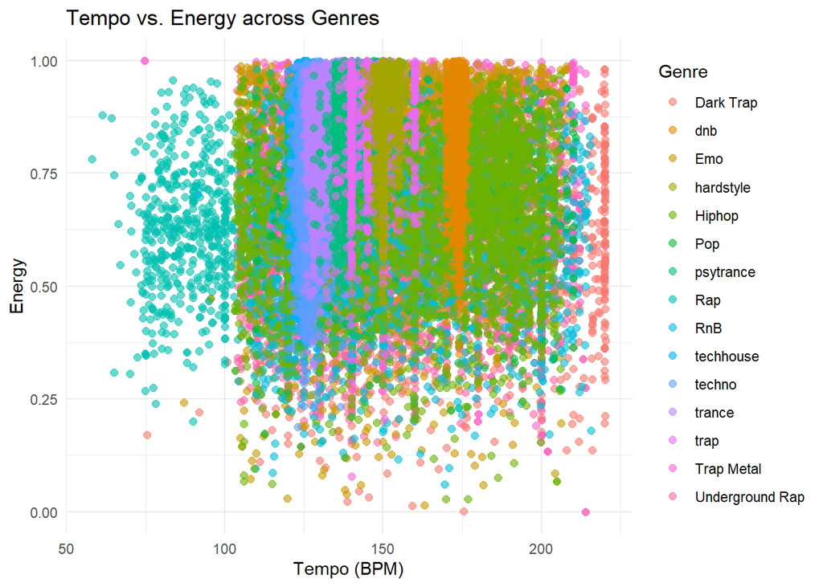

```r
print(p1)
```

**Relationship between Tempo and Energy across Genres:**

Correlation between Tempo and Energy: There does not appear to be a clear, consistent correlation between faster tempos and higher energy across all genres. While some genres may show this trend, it’s not a universal rule applicable to all.

Genre-Specific Patterns: The relationship between tempo and energy varies significantly by genre. Some genres, possibly like electronic or dance music, might show a trend where higher tempo correlates with higher energy. In contrast, other genres, such as classical or jazz, might not exhibit such a strong correlation, having both high-energy fast tracks and low-energy fast tracks.

Diverse Energy Levels at Similar Tempos: At any given tempo, there’s a wide range of energy levels. This suggests that tempo alone doesn’t dictate the energy level of a track, and other factors like instrumentation, rhythm complexity, and production techniques also play significant roles.

High Tempo Doesn’t Always Mean High Energy: There are numerous points in the higher tempo range (say above 140 BPM) that do not correspond to high energy levels. This indicates that fast songs are not always energetic.

Clusters and Overlaps: Some genres may cluster together, showing similar tempo-energy characteristics, while others overlap significantly, indicating shared attributes across genres.

Outliers: Any outliers on the plot (e.g., very high-energy tracks at lower tempos or vice versa) could be particularly interesting for further analysis, as they defy the common trends observed.

In conclusion, while there might be a general tendency for faster songs to be more energetic in certain genres, this plot demonstrates that it’s not a universal rule across all genres. The relationship between tempo and energy is complex and influenced by genre-specific characteristics.

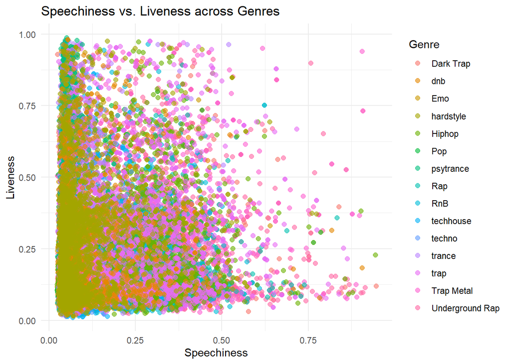

```r
print(p2)
```

**Relationship between Speechiness and Liveness across Genres:**

General Distribution: The majority of tracks, regardless of genre, tend to have low speechiness and liveness levels. This suggests that instrumental music or tracks with limited spoken words are more common, and most tracks are studio-recorded rather than live recordings.

Concentration of Points: Most genres seem to cluster in the lower left corner of the plot (low speechiness and low liveness), indicating that tracks with high levels of speechiness or liveness are less common.

High Speechiness and Liveness: There are few tracks with both high speechiness and high liveness. This might represent specific genres like live rap or spoken word performances where spoken content is predominant in a live setting.

Genre Variation: Some genres might show a tendency towards higher speechiness or liveness, but the plot does not clearly segregate genres based on these two features. This indicates that speechiness and liveness alone might not be strong distinguishing factors for genres.

Sparse High Liveness: Tracks with higher liveness (towards the top of the plot) are relatively sparse, suggesting that live recordings or tracks with audience interaction are less frequent in the dataset.

Outliers: There are some outliers, particularly in terms of high speechiness. These tracks could be interesting to explore further, as they might represent genres or styles that heavily focus on spoken words, like hip-hop, rap, or certain types of electronic music.

Lack of Strong Correlation: There is no clear pattern or strong correlation suggesting that higher speechiness consistently leads to higher liveness or vice versa. This might imply that the presence of spoken words in a track does not necessarily mean the track is a live recording.

These observations provide an overview of how speechiness and liveness characteristics are distributed across different genres. However, the specific insights and interpretations could vary depending on the details and nuances of the dataset.

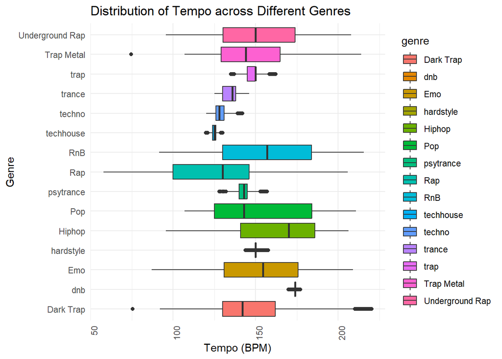

```r
print(p3)
```

**Distribution of Tempo across Genres:**

The boxplot above illustrates the distribution of tempo (measured in Beats Per Minute, BPM) across different music genres. Here are some observations from the plot:

Variability in Tempo: Each genre has a unique distribution of tempo, with some genres showing a wider range of tempos than others. This reflects the rhythmic diversity present within each genre.

Median Tempo: The median tempo (indicated by the line in the middle of each box) varies significantly across genres. Some genres have higher median tempos, suggesting a generally faster pace, while others have lower median tempos.

Outliers: The presence of outliers (indicated by dots outside the boxes) in several genres suggests that there are songs with tempos that are significantly different from the majority in that genre. These could represent sub-genres or experimental tracks that deviate from the norm.

Interquartile Range (IQR): The height of each box (representing the IQR) shows the spread of the middle 50% of the data. A taller box implies greater variability in tempo within that genre.

Comparisons Between Genres: Some genres have overlapping IQRs, indicating similarities in tempo range, while others are distinctly separate, indicating unique tempo characteristics.

Genre-Specific Characteristics: The plot allows for the identification of genre-specific tempo characteristics. For example, some electronic or dance-oriented genres might show consistently higher tempos, while genres like jazz or classical might have a broader range of tempos.

This visualization is effective for comparing tempo distributions across genres and identifying unique tempo-related characteristics inherent to specific styles of music.

[figure not shown]

```r
print(p4)
```

**Relation ship of Mode (Major vs. Minor) Distribution across Genres :**

Mode Preference by Genre: The plot reveals that certain genres have a strong preference for either major or minor mode. For example, some genres might predominantly feature major mode tracks, indicating a preference for a brighter or happier tonality, while others might lean towards minor mode, often associated with a sadder or more serious tonality.

Genre-Specific Trends: There are clear genre-specific trends in mode preference. Some genres show a relatively balanced distribution of major and minor modes, while others are heavily skewed towards one.

Dominant Mode in Genres: In several genres, one mode (either major or minor) dominates. This dominance can be indicative of the overall mood and style typical of that genre.

Comparison Across Genres: The comparison across genres in terms of mode distribution can offer insights into the stylistic and emotional differences between them. Genres with a similar distribution might have comparable emotional or stylistic attributes.

Cultural and Contextual Influences: The mode distribution could also reflect cultural or contextual influences in music production and genre evolution. For instance, certain cultural music styles might have a historical or traditional inclination towards a particular mode.

Variability in Distribution: Some genres show a significant amount of variability in their mode distribution, suggesting a diversity of musical styles within those genres.

This analysis is particularly useful for understanding the tonal characteristics of different genres and how they relate to the emotional or mood aspects of music.

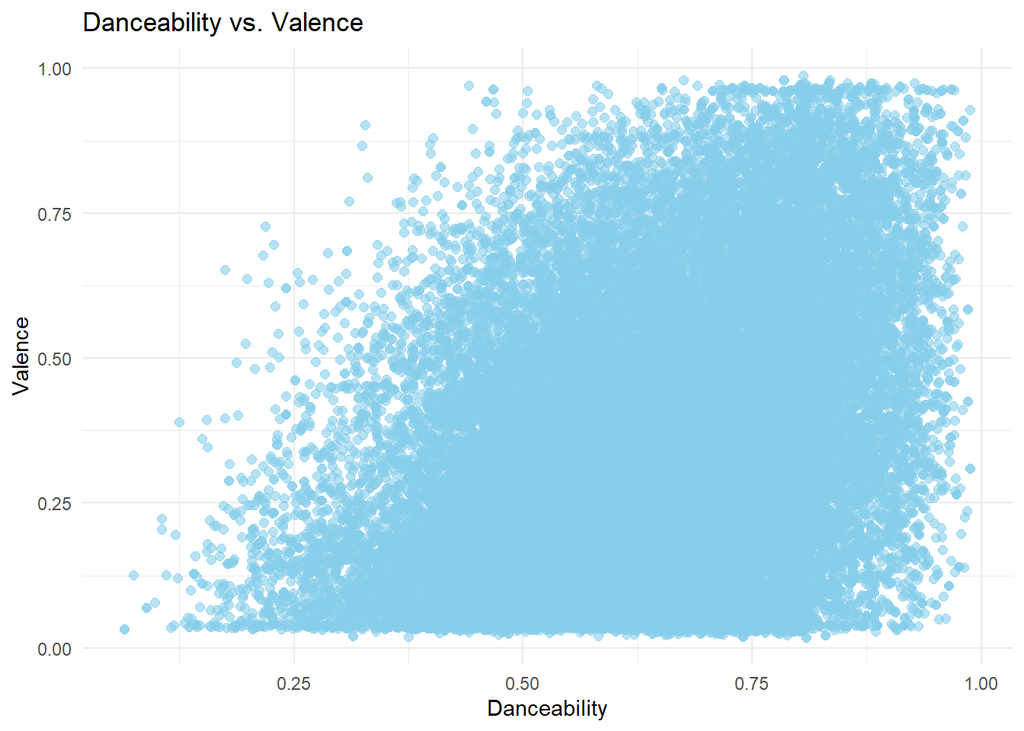

```r
print(p5)
```

**Relationship between Danceability and Valence :**

General Trend: There doesn’t appear to be a strong, consistent linear correlation between danceability and valence. While there are a significant number of tracks that are both highly danceable and have high valence, there are also many tracks with high danceability and low valence.

Variability Across the Spectrum: Both danceability and valence exhibit a wide range of values, indicating a diverse set of tracks in terms of their musical and emotional characteristics.

Clusters of Tracks: There are clusters of tracks with high danceability and high valence, which might indicate genres or styles that are both upbeat and danceable. Similarly, there are clusters with high danceability but lower valence.

No Clear Genre Segregation: Without color-coding by genre, it’s challenging to discern clear genre-specific patterns from this plot alone. The distribution of points suggests that both danceable and emotionally positive traits are not confined to specific genres.

Outliers: There are tracks that deviate from the general clustering, such as those with high valence but lower danceability, and vice versa. These tracks might represent unique or niche musical styles.

This analysis suggests that while danceable music often tends to be more positive, this is not a rule, and there is considerable variability in the emotional tone of danceable tracks.

# **SMART Questions**

Now, Let us focus on a particular feature ‘Danceability’. Danceability, as a measure of a song’s ability to create a dance-friendly environment, is influenced by a myriad of musical features. Our goal is to unravel these hidden patterns and understand the underlying relationships.

Danceability holds paramount importance in the realm of music as it serves as a gateway to a rich tapestry of experiences. More than a mere metric, danceability reflects a song’s capacity to inspire physical movement, transforming the act of listening into a dynamic and participatory engagement. Beyond personal enjoyment, danceability fosters social connections, acting as a catalyst for communal celebrations and shared moments on dance floors. Culturally, it contributes to the preservation and expression of traditions, while in the realm of entertainment, it shapes live performances and events, enhancing their vibrancy. Additionally, danceability intersects with health and well-being, as it often accompanies fitness activities, making physical exertion more enjoyable.

So now coming to our first SMART question-

**1) How do specific music features such as energy, loudness, speechiness, etc contribute to the perceived danceability of a song, and can we uncover latent patterns within these features that significantly impact danceability?**

Let us divide this question into 2 parts-

1. How do individual music features contribute to the perceived danceability of a song?
2. Can we uncover latent patterns within these features that significantly impact danceability and How accurately can these features predict danceability using a regression model?

To answer the first part of the question let us turn our attention to visualizing the intricate relationship between danceability and various key musical features. Utilizing a diverse set of visualizations, we aim to uncover patterns, tendencies, and nuances that contribute to danceability perception.

```r
df<-dataset_na
```

The correlation matrix offers an initial insight into the linear connections among danceability and various musical attributes like energy, valence, speechiness, acousticness, and instrumentalness. Acting as a fundamental tool, this matrix aids in comprehending the direction and robustness of associations, steering our investigation into the intricate interrelationships among these features.

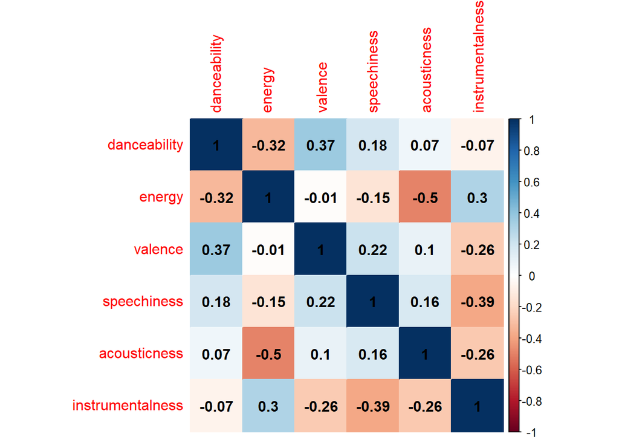

```r
# Correlation matrix
correlation_matrix <- cor(df[, c('danceability', 'energy', 'valence', 'speechiness', 'acousticness', 'instrumentalness')])
corrplot(correlation_matrix, method = 'color', addCoef.col = "black")
```

The correlation matrix reveals notable associations involving danceability. Specifically, a negative correlation with energy suggests that as energy levels decrease, danceability tends to increase. Conversely, a positive correlation with valence indicates that higher positivity in tracks is linked to greater danceability. The positive correlation with speechiness implies that tracks with more speech-like elements tend to be more danceable. However, danceability shows weaker correlations with both acousticness and instrumentalness, suggesting that its relationship with these features is less pronounced. These findings provide a nuanced comprehension of how danceability interacts with energy, valence, and speechiness, supplying valuable insights for the analysis and interpretation of musical characteristics contributing to perceived danceability.

Expanding our analysis beyond mere correlation, we explore genre-specific nuances through the utilization of box plots. These visual representations of danceability across diverse genres aim to uncover trends and variations unique to each genre. This genre-centric strategy enables us to distinguish whether specific music genres inherently exhibit tendencies toward higher or lower danceability scores.

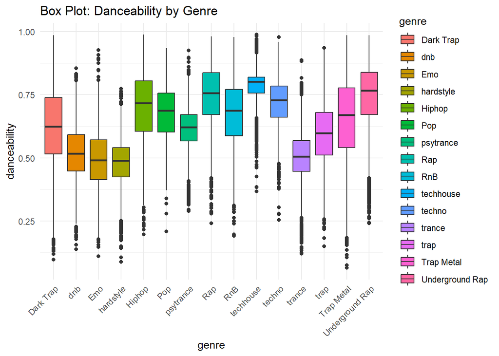

```r
# Box plot: Danceability by Genre
ggplot(df, aes(x = genre, y = danceability, fill = genre)) +
  geom_boxplot() +
  ggtitle('Box Plot: Danceability by Genre') +
  theme_minimal() +
  theme(axis.text.x = element_text(angle = 45, hjust = 1))
```

Embarking on a rhythmic journey through the vast landscape of musical genres, we eagerly explore the danceability levels that lie hidden within the beats and melodies of each unique style. These box plots serve as gateways to distinct genre-specific territories, each a kingdom with its own unique danceability narrative. Previously perceived as danceable titans, genres like Dark Trap, Trap Metal, and Emo defy expectations, revealing a more nuanced and restrained danceability. This revelation challenges our initial assumptions, prompting a reevaluation of these musical realms. In stark contrast, the domains of Hiphop and Rap unfold as rhythmic treasure troves, where meticulously crafted beats beckon listeners into a captivating dance-induced reverie.

Further, we investigate the impact of discrete features, specifically ‘key’ and ‘mode,’ on danceability through individualized box plots. These plots provide a fine-grained examination of how these categorical features influence the perceived danceability of songs.

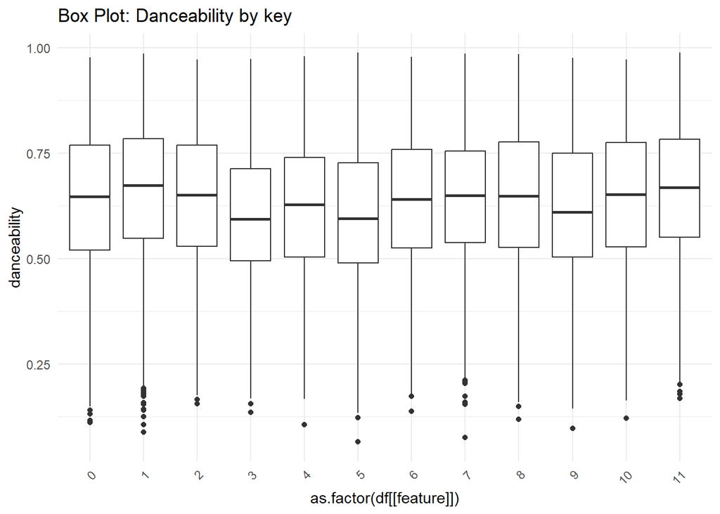

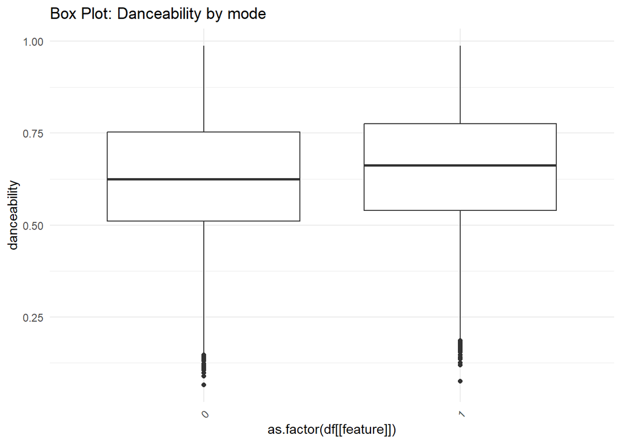

```r
  for (feature in c('key', 'mode')) {
    p <- ggplot(df, aes(x = as.factor(df[[feature]]), y = danceability)) +
      geom_boxplot() +
      ggtitle(paste('Box Plot: Danceability by', feature)) +
      theme_minimal() +
      theme(axis.text.x = element_text(angle = 45, hjust = 1))

    print(p)
  }
```

Exploring different musical modes, we find that Mode 1 takes the spotlight with a higher average danceability than Mode 0. While Mode 1 grabs attention with its elevated danceability, it shows a bit less variety in danceability scores. This mix of keys and modes adds unique flavors to the overall danceability tale, with each key and mode bringing its own distinctive style to the world of music perception.

Next let us try to focus on the second part of the SMART question 1(b)-

We are going to be using the Principal Component Analysis followed by a regression model to answer this part of the question. To understand how specific music features contribute to the perceived danceability of a song and uncover latent patterns within these features, Principal Component Analysis (PCA) and regression models can be valuable tools. Regression models, such as linear regression, can be employed to quantify the relationships between individual music features and danceability. By fitting a regression model with danceability as the dependent variable and energy, loudness, speechiness, and other relevant features as independent variables, one can estimate the impact and significance of each feature on danceability. After applying PCA, the principal components that emerge can be used as predictors in regression models.

Principal Component Analysis (PCA) is a technique frequently employed for diminishing the dimensionality of extensive data sets. This method involves transforming a substantial set of variables into a more compact one while retaining the majority of information from the original dataset. Although reducing variables inevitably leads to a loss of precision, the key in dimensionality reduction is to strike a balance, sacrificing some accuracy for the sake of simplicity. The advantage lies in the ease of exploration, visualization, and accelerated processing of data points for machine learning algorithms, as smaller datasets are more manageable and efficient without unnecessary variables.**[5]**

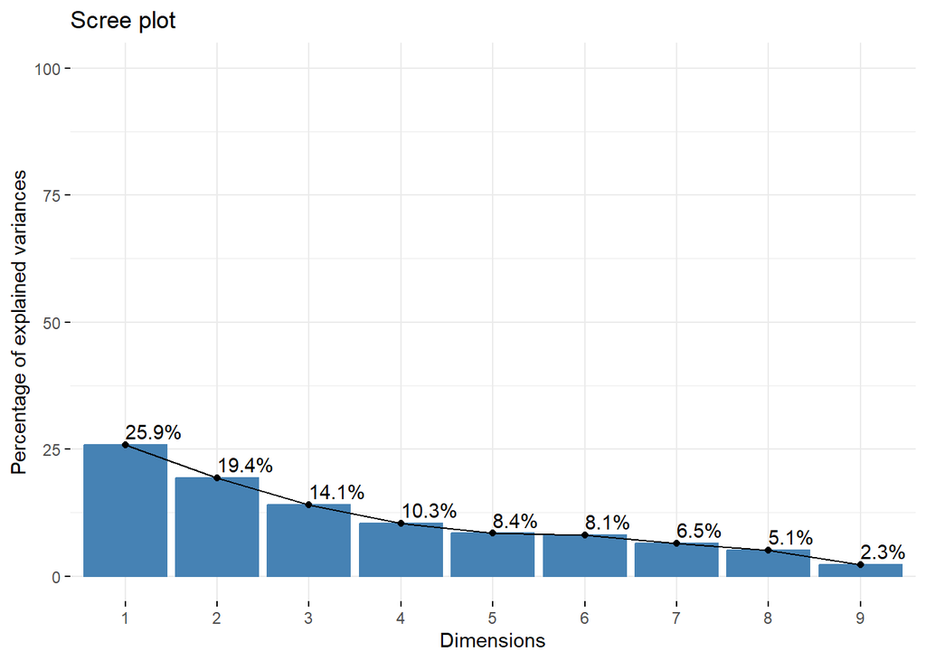

```r
music_data <- dataset_na

# Selecting relevant features for PCA
selected_features <- c("danceability", "energy", "loudness", "speechiness", "acousticness", "instrumentalness", "liveness", "valence", "tempo")
subset_data <- music_data[, selected_features]

# PCA
music_pca <- PCA(subset_data, graph = FALSE)

# Scree plot
fviz_screeplot(music_pca, addlabels = TRUE, ylim = c(0, 100))
```

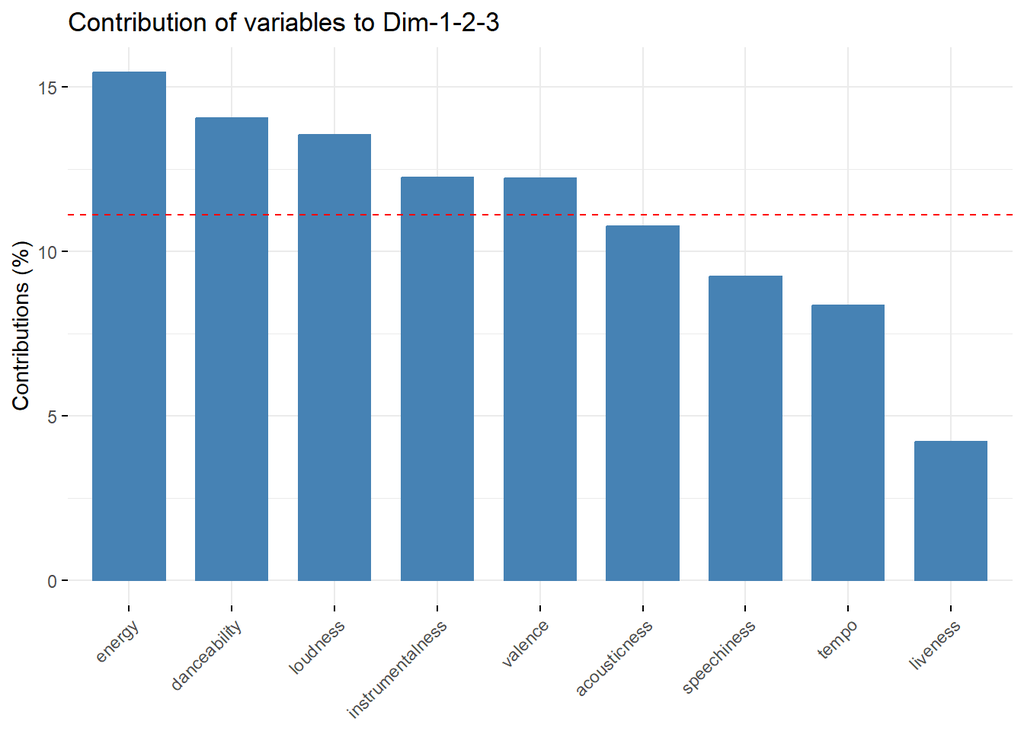

```r
# Variable contributions
fviz_contrib(music_pca, choice = "var", axes = 1:3, top = 10)
```

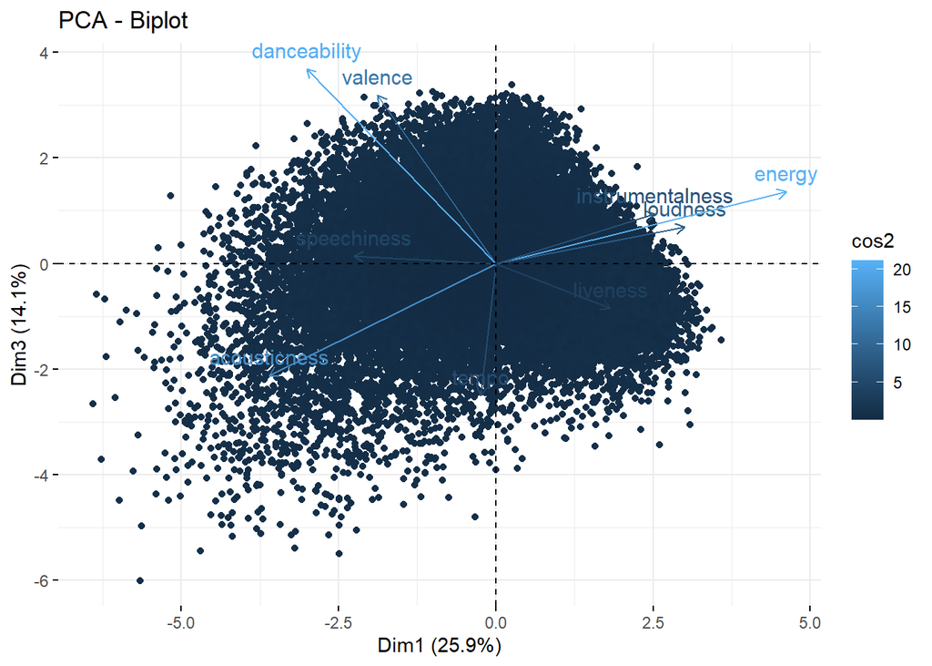

```r
# Biplot
fviz_pca_biplot(music_pca, axes = c(1,3), geom = "point", col.ind = "cos2", col.var = "contrib")
```

```r
eigenvalues <- music_pca$eig

# Get variable contributions
var_contributions <- as.data.frame(music_pca$var$contrib)


# Output results
eigenvalues
```

```
##        eigenvalue percentage of variance cumulative percentage of variance
## comp 1  2.3268354              25.853726                          25.85373
## comp 2  1.7442198              19.380220                          45.23395
## comp 3  1.2677667              14.086296                          59.32024
## comp 4  0.9305339              10.339266                          69.65951
## comp 5  0.7574965               8.416628                          78.07614
## comp 6  0.7279538               8.088376                          86.16451
## comp 7  0.5827511               6.475012                          92.63952
## comp 8  0.4551949               5.057721                          97.69725
## comp 9  0.2072479               2.302754                         100.00000
```

```r
var_contributions
```

```
##                        Dim.1       Dim.2       Dim.3        Dim.4      Dim.5
## danceability     12.78277149  0.23372311 35.36527805 4.827135e-02  4.6914705
## energy           30.14041762  3.55280844  4.77804294 2.409884e-01  0.2409893
## loudness         12.75159572 23.51043709  1.22614973 3.341847e+00 13.5710415
## speechiness       7.17270082 18.61743828  0.04806037 4.231978e+00  1.0852124
## acousticness     18.33183067  0.01267747 11.69185204 1.196179e+00  8.0368190
## instrumentalness  9.05005943 23.67939798  2.30699343 7.195122e-05 17.9630642
## liveness          4.70400122  5.21118286  1.87662696 7.008332e+01  8.4254794
## valence           4.98767130 11.55731771 26.41456514 1.251455e-01  1.7214212
## tempo             0.07895172 13.62501706 16.29243134 2.073220e+01 44.2645024
```

The Principal Component Analysis (PCA) results provide valuable insights into the latent patterns within music features and their impact on danceability. The eigenvalues and the percentage of variance explained by each component offer an understanding of the overall data structure. For instance, the first five components cumulatively capture 78.08% of the variance, suggesting that a substantial amount of information is retained within these dimensions.

The eigenvalues and the percentage of variance explained by each component indicate the amount of information captured by that component. In this case, the first component explains 25.85% of the variance, and the second component explains 19.38% of the variance, with the cumulative percentage of variance increasing as we consider more components. This information is useful for determining the number of components to retain in the analysis. The variable contributions show how much each musical feature contributes to each principal component. For example, in the first component, “energy” has a high contribution (30.14%), while “danceability” also has a significant contribution (12.78%). This information can be used to understand which features are most important for each component and, by extension, for predicting danceability.

Moreover, examining the variable contributions to each principal component sheds light on how specific features contribute to the identified patterns. To assess the predictive power of these features on danceability, regression models can be built using the principal components as predictors. The contributions of each variable to different components guide us in understanding which features are crucial for explaining the observed patterns. The cumulative percentage of variance helps determine the optimal number of components to include in the model.

The PCA results offer a comprehensive exploration of latent patterns in the data and provide a foundation for constructing regression models to predict danceability based on the identified principal components.As we are able to see that the principal components with the highest contributions to danceability are “Dim.1” followed by “Dim.3.” and so on. “Dim.1” and “Dim.3” refer to the principal components themselves, each representing a linear combination of the original variables (in this case, musical features) in the dataset. These components are derived in such a way that they capture the maximum variance in the data.

Utilizing these components in a regression model might allow us to capture the most significant patterns and variations in danceability based on the underlying features in the dataset.

```r
linear_model <- lm(danceability ~ music_pca$ind$coord[, c("Dim.1", "Dim.2", "Dim.3", "Dim.4", "Dim.5")], data = dataset)
summary(linear_model)
```

```
##
## Call:
## lm(formula = danceability ~ music_pca$ind$coord[, c("Dim.1",
##     "Dim.2", "Dim.3", "Dim.4", "Dim.5")], data = dataset)
##
## Residuals:
##      Min       1Q   Median       3Q      Max
## -0.34879 -0.04760  0.00210  0.04894  0.31507
##
## Coefficients:
##                                                                              Estimate
## (Intercept)                                                                 0.6393643
## music_pca$ind$coord[, c("Dim.1", "Dim.2", "Dim.3", "Dim.4", "Dim.5")]Dim.1 -0.0559947
## music_pca$ind$coord[, c("Dim.1", "Dim.2", "Dim.3", "Dim.4", "Dim.5")]Dim.2 -0.0075716
## music_pca$ind$coord[, c("Dim.1", "Dim.2", "Dim.3", "Dim.4", "Dim.5")]Dim.3  0.0931371
## music_pca$ind$coord[, c("Dim.1", "Dim.2", "Dim.3", "Dim.4", "Dim.5")]Dim.4  0.0034410
## music_pca$ind$coord[, c("Dim.1", "Dim.2", "Dim.3", "Dim.4", "Dim.5")]Dim.5  0.0339226
##                                                                            Std. Error
## (Intercept)                                                                 0.0003524
## music_pca$ind$coord[, c("Dim.1", "Dim.2", "Dim.3", "Dim.4", "Dim.5")]Dim.1  0.0002310
## music_pca$ind$coord[, c("Dim.1", "Dim.2", "Dim.3", "Dim.4", "Dim.5")]Dim.2  0.0002668
## music_pca$ind$coord[, c("Dim.1", "Dim.2", "Dim.3", "Dim.4", "Dim.5")]Dim.3  0.0003130
## music_pca$ind$coord[, c("Dim.1", "Dim.2", "Dim.3", "Dim.4", "Dim.5")]Dim.4  0.0003653
## music_pca$ind$coord[, c("Dim.1", "Dim.2", "Dim.3", "Dim.4", "Dim.5")]Dim.5  0.0004049
##                                                                             t value
## (Intercept)                                                                1814.333
## music_pca$ind$coord[, c("Dim.1", "Dim.2", "Dim.3", "Dim.4", "Dim.5")]Dim.1 -242.381
## music_pca$ind$coord[, c("Dim.1", "Dim.2", "Dim.3", "Dim.4", "Dim.5")]Dim.2  -28.376
## music_pca$ind$coord[, c("Dim.1", "Dim.2", "Dim.3", "Dim.4", "Dim.5")]Dim.3  297.585
## music_pca$ind$coord[, c("Dim.1", "Dim.2", "Dim.3", "Dim.4", "Dim.5")]Dim.4    9.419
## music_pca$ind$coord[, c("Dim.1", "Dim.2", "Dim.3", "Dim.4", "Dim.5")]Dim.5   83.781
##                                                                            Pr(>|t|)
## (Intercept)                                                                  <2e-16
## music_pca$ind$coord[, c("Dim.1", "Dim.2", "Dim.3", "Dim.4", "Dim.5")]Dim.1   <2e-16
## music_pca$ind$coord[, c("Dim.1", "Dim.2", "Dim.3", "Dim.4", "Dim.5")]Dim.2   <2e-16
## music_pca$ind$coord[, c("Dim.1", "Dim.2", "Dim.3", "Dim.4", "Dim.5")]Dim.3   <2e-16
## music_pca$ind$coord[, c("Dim.1", "Dim.2", "Dim.3", "Dim.4", "Dim.5")]Dim.4   <2e-16
## music_pca$ind$coord[, c("Dim.1", "Dim.2", "Dim.3", "Dim.4", "Dim.5")]Dim.5   <2e-16
##
## (Intercept)                                                                ***
## music_pca$ind$coord[, c("Dim.1", "Dim.2", "Dim.3", "Dim.4", "Dim.5")]Dim.1 ***
## music_pca$ind$coord[, c("Dim.1", "Dim.2", "Dim.3", "Dim.4", "Dim.5")]Dim.2 ***
## music_pca$ind$coord[, c("Dim.1", "Dim.2", "Dim.3", "Dim.4", "Dim.5")]Dim.3 ***
## music_pca$ind$coord[, c("Dim.1", "Dim.2", "Dim.3", "Dim.4", "Dim.5")]Dim.4 ***
## music_pca$ind$coord[, c("Dim.1", "Dim.2", "Dim.3", "Dim.4", "Dim.5")]Dim.5 ***
## ---
## Signif. codes:  0 '***' 0.001 '**' 0.01 '*' 0.05 '.' 0.1 ' ' 1
##
## Residual standard error: 0.07248 on 42299 degrees of freedom
## Multiple R-squared:  0.7858, Adjusted R-squared:  0.7858
## F-statistic: 3.104e+04 on 5 and 42299 DF,  p-value: < 2.2e-16
```

```r
#Dividing the dataset for train and test-

# Combine PCA dimensions with the original dataset
full_dataset <- cbind(dataset, music_pca$ind$coord[, c("Dim.1", "Dim.2", "Dim.3", "Dim.4", "Dim.5")])

# Set seed for reproducibility
set.seed(123)

# Split the data (80% for training, 20% for testing)
sample_indices <- sample(1:nrow(full_dataset), 0.8 * nrow(full_dataset))
train_data <- full_dataset[sample_indices, ]
test_data <- full_dataset[-sample_indices, ]

# Fit the model on the training set
linear_model <- lm(danceability ~ Dim.1 + Dim.2 + Dim.3 + Dim.4 + Dim.5, data = train_data)

# Predict on the test set
predictions <- predict(linear_model, newdata = test_data)

# Evaluate performance (use appropriate metrics for your specific case)
mse <- mean((test_data$danceability - predictions)^2)
rmse <- sqrt(mse)
# Print or visualize the performance metrics
cat("Mean Squared Error:", mse, "\n")
```

```
## Mean Squared Error: 0.005279898
```

```r
cat("Root Mean Squared Error:", rmse, "\n")
```

```
## Root Mean Squared Error: 0.07266291
```

The regression analysis reveals compelling insights into the impact of principal components on danceability. The model, regressing danceability on the first five principal components (Dim.1 to Dim.5), demonstrates statistical significance, as indicated by extremely low p-values (all < 2e-16). The coefficients associated with each dimension unveil the direction and magnitude of their influence on danceability. Notably, Dim.1 and Dim.3 exhibit the most substantial effects, with Dim.1 contributing negatively and Dim.3 positively. This implies that songs with higher values of Dim.1 may have lower danceability, while those with higher Dim.3 values tend to be more danceable. The coefficient of determination (R-squared) for the regression model is 0.7858, indicating that approximately 78.58% of the variability in danceability can be explained by the first five principal components (Dim.1 to Dim.5).

To evaluate the predictive performance of the model, it is applied to a test set derived from the combination of the original dataset and the PCA dimensions. The mean squared error (MSE) and root mean squared error (RMSE) metrics provide measures of prediction accuracy. In this instance, the MSE is 0.005279898, and the RMSE is 0.07266291. These low error values suggest that the regression model effectively captures latent patterns within the features and can predict danceability with a high degree of accuracy. The combination of PCA and regression proves to be a robust approach for uncovering significant patterns influencing danceability and constructing a predictive model that accurately reflects these patterns.

Moving on to our second SMART Question-

**2) Are there certain genres that tend to have more lyrical content (higher speechiness)?**

Ever wonder how different music styles say what they say? Words play a big role, especially how “talky” they are.Across the vibrant tapestry of music genres, lyrics play a fascinating role in shaping a song’s emotional and thematic landscape. This analysis delves into the relationship between genres and speechiness, seeking to uncover patterns and distinctions in lyrical expression across different musical styles. By employing a box plot visualization, we aim to elucidate how speechiness varies within each genre, providing insights into whether certain genres tend to exhibit higher or lower lyrical content. Additionally, a correlation matrix is explored to understand the interplay between speechiness and other musical attributes, shedding light on potential associations that may influence lyrical richness.

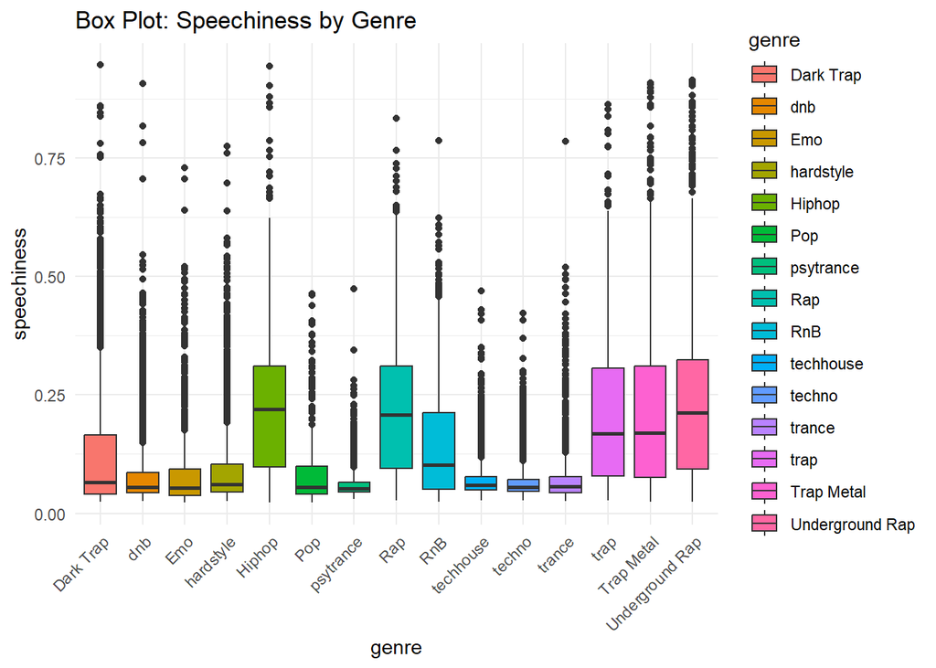

```r
p6 <- ggplot(dataset_na, aes(x = genre, y = speechiness, fill = genre)) +
  geom_boxplot() +
  ggtitle('Box Plot: Speechiness by Genre') +
  theme_minimal() +
  theme(axis.text.x = element_text(angle = 45, hjust = 1))

print(p6)
```

*Relationship of speechiness across genres:*

Genres like “Emo,” “dnb” (Drum and Bass), and “hardstyle” lean towards lower median speechiness, hinting at a preference for fewer spoken words. Conversely, genres like “Hiphop” and “Trap Metal” boast higher median values, indicating a more prominent role for spoken words in these musical landscapes.

These observations can provide insights into the characteristics of each genre and indicate how speechiness is a distinguishing feature in the dataset. When using this information for data analysis or machine learning, it would be important to consider how speechiness may help in differentiating between genres or contributing to the identity of a genre.

```r
genre_stats <- dataset_na %>%
  group_by(genre) %>%
  summarize(mean_speechiness = mean(speechiness),
            median_speechiness = median(speechiness))

print("Genre-Specific Statistics:")
```

```
## [1] "Genre-Specific Statistics:"
```

```r
print(genre_stats)
```

```
## # A tibble: 15 × 3
##    genre           mean_speechiness median_speechiness
##    <chr>                      <dbl>              <dbl>
##  1 Dark Trap                 0.123              0.0652
##  2 Emo                       0.0803             0.0536
##  3 Hiphop                    0.217              0.22
##  4 Pop                       0.0884             0.0555
##  5 Rap                       0.218              0.208
##  6 RnB                       0.143              0.102
##  7 Trap Metal                0.210              0.169
##  8 Underground Rap           0.225              0.213
##  9 dnb                       0.0835             0.0555
## 10 hardstyle                 0.0946             0.0606
## 11 psytrance                 0.0604             0.0525
## 12 techhouse                 0.0723             0.0601
## 13 techno                    0.0662             0.0553
## 14 trance                    0.0713             0.0561
## 15 trap                      0.206              0.168
```

Examining the genre-specific statistics unveils intriguing patterns in speechiness similar to the plot across a spectrum of musical genres. Genres like Hiphop, Rap, Trap Metal, and Underground Rap exhibit higher mean speechiness values, suggesting a predominant emphasis on spoken words within their compositions. Conversely, genres such as Emo, dnb (Drum and Bass), and hardstyle lean towards lower mean speechiness, implying a proclivity for fewer spoken words. The median speechiness values further emphasize these trends, with Hiphop and Trap Metal standing out with notably higher median values compared to genres like Emo and Pop. This detailed statistical exploration provides a nuanced understanding of how speechiness varies across genres, shedding light on the distinctive lyrical tendencies that define each musical category.

Next we have a corellation matrix -

```r
correlation_matrix <- cor(dataset_na[, c('speechiness', 'energy', 'valence', 'tempo')])
print("Correlation Matrix:")
```

```
## [1] "Correlation Matrix:"
```

```r
print(correlation_matrix)
```

```
##             speechiness      energy     valence       tempo
## speechiness   1.0000000 -0.14836273  0.21882904  0.16467422
## energy       -0.1483627  1.00000000 -0.01351969 -0.02450386
## valence       0.2188290 -0.01351969  1.00000000  0.05837415
## tempo         0.1646742 -0.02450386  0.05837415  1.00000000
```

Delving into the correlation matrix uncovers subtle relationships between speechiness and other musical attributes. The negative correlation between speechiness and energy suggests that genres with higher speechiness may align with lower energy levels, while the positive correlations with valence and tempo indicate potential synergies in emotional expression and rhythmic elements of lyrical content. These nuanced correlations contribute to a more comprehensive understanding of the intricate interplay between spoken words and other musical features. The correlation matrix thus serves as a valuable tool for unraveling the complex web of connections within the dataset, enhancing our appreciation of how lyrical content interacts with broader musical characteristics.

In conclusion, certain genres, particularly those within the Hiphop and Rap umbrella, tend to have more lyrical content, as evidenced by higher mean and median speechiness values. These genres exhibit distinct patterns in their lyrical tendencies, setting them apart from genres that emphasize fewer spoken words. The correlation matrix further illuminates the subtle relationships between speechiness and other musical attributes, providing a holistic view of how lyrical content intertwines with broader musical features.

Next we have our Final SMART question-

**3) How accurate are models in predicting the genre of songs in the dataset based on the given features?**

To answer this question we have chosen these 4 models with their reason for use and their nature mentioned-

*RandomForest:*

Nature: Random Forest stands out as a popular machine learning algorithm created by Leo Breiman and Adele Cutler. It is an ensemble learning method based on decision tree algorithms. It operates by constructing a multitude of decision trees during training and outputting the mode of the classes (classification) of the individual trees.**[6]**

Why Chosen: It’s known for its robustness and ability to handle large datasets with a mix of numerical and categorical features. RandomForest is effective in reducing overfitting by averaging the results of individual trees, thereby improving generalization. It’s also good at handling missing data and maintains accuracy even when a significant proportion of the data is missing.

*Gradient Boosting:*

Nature: Gradient Boosting is another ensemble technique that builds trees sequentially, with each tree trying to correct the errors made by the previous ones.Basically it is a powerful boosting algorithm that combines several weak learners into strong learners, in which each new model is trained to minimize the loss function such as mean squared error or cross-entropy of the previous model using gradient descent.**[7]**

Why Chosen: It’s highly effective in classification tasks due to its ability to minimize both bias and variance, leading to more accurate models. It’s particularly useful in scenarios where the relationship between features and target variable is complex and non-linear. The model’s flexibility allows it to capture intricate patterns in the data.

*XGBoost:*

Nature: XGBoost, which stands for Extreme Gradient Boosting, is a scalable, distributed gradient-boosted decision tree (GBDT) machine learning library. It provides parallel tree boosting and is the leading machine learning library for regression, classification, and ranking problems.**[8]**

Why Chosen: XGBoost provides a highly efficient implementation of the gradient boosting algorithm. It’s not only faster but also has built-in mechanisms for handling missing data. Additionally, XGBoost includes regularization, which helps to prevent overfitting and can lead to better performance on unseen data. It’s particularly popular due to its speed and performance.

*K-Nearest Neighbors (KNN):*

Nature: The k-nearest neighbors algorithm, also known as KNN or k-NN, is a non-parametric, supervised learning classifier, which uses proximity to make classifications or predictions about the grouping of an individual data point.**[9]**

Why Chosen: KNN was chosen as a contrasting approach to ensemble methods. It’s a straightforward and intuitive algorithm that works well when the dataset has a number of instances where similar cases are near each other in the feature space. It was included to see if a simpler approach could effectively handle the genre classification task without the complexities of ensemble methods.

Each of these models brings a different approach to the table: RandomForest and Gradient Boosting for their ensemble-based robustness, XGBoost for its efficiency and performance, and KNN for its simplicity and intuitive operation. The combination of these models offers a well-rounded perspective on how various machine learning techniques perform on the genre classification task, providing insights into the complexity and challenges of the dataset.

```r
dataset_na$genre <- as.factor(dataset_na$genre)
```

Splitting the data into Test and Train set-

```r
set.seed(123)
train_indices <- sample(1:nrow(dataset_na), nrow(dataset_na) * 0.8)
train_data <- dataset_na[train_indices, ]
test_data <- dataset_na[-train_indices, ]
```

1. Random Forest Model to Predict Genre-

```r
library(randomForest)
library(caret)
rf_model <- randomForest(genre ~ ., data = train_data, ntree = 100)
```

Feature importance-

```r
feature_importance <- importance(rf_model)

print(colnames(feature_importance))
```

```
## [1] "MeanDecreaseGini"
```

```r
top_features <- sort(feature_importance[, 'MeanDecreaseGini'], decreasing = TRUE)[1:10]


print(top_features)
```

```
##            tempo      duration_ms     danceability instrumentalness
##         6371.904         3827.463         2872.468         2695.058
##         loudness           energy      speechiness          valence
##         2602.470         2390.019         2087.791         2068.499
##     acousticness         liveness
##         2040.057         1586.163
```

Tempo:

Observation: The tempo of a song, measured in beats per minute (BPM), is the most influential feature in predicting its genre. Impact on Genre: Different genres tend to have characteristic tempos. For example, genres like techno or trance typically have a higher BPM, while genres like RnB or pop might have a slower tempo.

Duration_ms (Duration in milliseconds):

Observation: The length of the song is a significant predictor of its genre. Impact on Genre: Certain genres are known for their typical song lengths. For instance, genres like pop or radio-friendly tracks might have shorter durations, whereas genres like progressive or trance might feature longer tracks.

Danceability:

Observation: Danceability describes how suitable a track is for dancing based on a combination of musical elements including tempo, rhythm stability, beat strength, and overall regularity. Impact on Genre: Genres like electronic dance music (EDM) or pop are often high in danceability, whereas genres such as ambient or classical might have lower danceability scores.

Instrumentalness:

Observation: This feature predicts whether a track contains no vocals. The closer the instrumentalness value is to 1.0, the greater likelihood the track contains no vocal content. Impact on Genre: Genres like techno, ambient, or instrumental jazz often have high instrumentalness. In contrast, genres such as rap or pop typically have lower scores due to the prominent vocal content.

Loudness:

Observation: Loudness is the quality of a sound that is the primary psychological correlate of physical strength (amplitude). Impact on Genre: Genres like rock, metal, or EDM often have higher loudness levels, while acoustic or classical genres tend to be quieter.

Energy:

Observation: Energy represents a perceptual measure of intensity and activity. Typically, energetic tracks feel fast, loud, and noisy. Impact on Genre: High-energy genres include rock, metal, and EDM. In contrast, genres like jazz, classical, or RnB might exhibit lower energy levels.

Valence:

Observation: Valence measures the musical positiveness conveyed by a track. High valence sounds more positive (e.g., happy, cheerful, euphoric), while low valence sounds more negative (e.g., sad, depressed, angry). Impact on Genre: Genres like pop or certain strands of electronic music often have high valence, reflecting their generally upbeat nature. In contrast, genres like blues or some forms of metal might have lower valence, reflecting more somber or aggressive themes.

In summary, various musical features hold distinct significance in predicting genre. Tempo and duration shape the structural characteristics of a song, while danceability, instrumentalness, loudness, energy, and valence contribute to the emotional and stylistic aspects. Each feature illuminates specific traits that align with certain genres, underscoring the multifaceted nature of genre prediction based on musical attributes. Understanding the importance of these features provides valuable insights into the diverse musical landscape and the nuanced interplay between musical elements and genre classification.

Proceeding with the model-

```r
top_features_traindata <- train_data[, c("tempo", "duration_ms", "danceability", "instrumentalness","loudness","energy","valence","genre")]

top_features_testdata <- test_data[, c("tempo", "duration_ms", "danceability", "instrumentalness","loudness","energy","valence","genre")]


rf_model <- randomForest(genre ~ ., data=top_features_traindata, ntree=100)
```

```r
library(caret)
predictions <- predict(rf_model, top_features_testdata)
confusion_matrix <- confusionMatrix(predictions, top_features_testdata$genre)
print(confusion_matrix)
```

```
## Confusion Matrix and Statistics
##
##                  Reference
## Prediction        Dark Trap dnb Emo hardstyle Hiphop Pop psytrance Rap RnB
##   Dark Trap             412   1  17         7     53   5         5  18  19
##   dnb                     7 586   5         0      3   0         0   0   0
##   Emo                    14   3 199         5     21  20         0   5  26
##   hardstyle              20   0  10       483      3   1         1   1   1
##   Hiphop                 20   1  17         0    234   6         0  29 100
##   Pop                     1   0  13         0      2   5         0   1   1
##   psytrance               4   0   0        13      0   0       538   0   0
##   Rap                    23   0   2         0     34   2         0 111  14
##   RnB                    17   0  38         0     79  25         0  32 157
##   techhouse               7   0   0         0      2   3         1   0   1
##   techno                  4   0   0         0      0   0        11   0   0
##   trance                 53   0  14         0      2   1        12   0   2
##   trap                   18   0   3        28      1   2         6   0   1
##   Trap Metal             71   2   1         2      8   2         0   4   2
##   Underground Rap       265   1  27         0    215  22         0 169 100
##                  Reference
## Prediction        techhouse techno trance trap Trap Metal Underground Rap
##   Dark Trap               5      5     28   26         83             203
##   dnb                     0      0      0    1          2               4
##   Emo                     1      0      6    9          9              19
##   hardstyle               0      0      0   48          3               1
##   Hiphop                  0      0      0    1          6             156
##   Pop                     0      0      0    0          0               0
##   psytrance               0     14     15    3          0               0
##   Rap                     0      0      0    1          6              76
##   RnB                     0      1      2    2          2              44
##   techhouse             550     47      3    0          3               4
##   techno                 42    539     24    0          0               0
##   trance                  5     28    474    3          1               1
##   trap                    0      0      1  497          5               2
##   Trap Metal              0      0      2    1        102              96
##   Underground Rap         6      0      5   13        143             549
##
## Overall Statistics
##
##                Accuracy : 0.6425
```

[output cut: 31 more lines]

```
## Pos Pred Value          0.39348          0.88567       0.86935       0.79530
## Neg Pred Value          0.96688          0.99247       0.98788       0.98907
## Prevalence              0.05011          0.07198       0.07493       0.06619
## Detection Rate          0.01856          0.06500       0.06370       0.05602
## Detection Prevalence    0.04716          0.07340       0.07328       0.07044
## Balanced Accuracy       0.67009          0.94704       0.91990       0.91549
##                      Class: trap Class: Trap Metal Class: Underground Rap
## Sensitivity              0.82149           0.27945                0.47532
## Specificity              0.99147           0.97641                0.86778
## Pos Pred Value           0.88121           0.34812                0.36238
## Neg Pred Value           0.98632           0.96780                0.91276
## Prevalence               0.07150           0.04314                0.13651
## Detection Rate           0.05874           0.01206                0.06489
## Detection Prevalence     0.06666           0.03463                0.17906
## Balanced Accuracy        0.90648           0.62793                0.67155
```

```r
confusion_matrix$overall
```

```
##       Accuracy          Kappa  AccuracyLower  AccuracyUpper   AccuracyNull
##      0.6424772      0.6103592      0.6321583      0.6526980      0.1365087
## AccuracyPValue  McnemarPValue
##      0.0000000            NaN
```

The RandomForest model trained with the top 7 features achieved an accuracy of approximately 64.24% on the test set. Here is a more detailed performance breakdown by genre:

Precision: Indicates the accuracy of positive predictions for each genre. Genres like ‘dnb’, ‘hardstyle’, ‘psytrance’, ‘techhouse’, ‘techno’, ‘trance’, and ‘trap’ show high precision, meaning the model is quite accurate in identifying these genres.

Recall: Shows the ability of the model to find all relevant instances of a genre. Again, genres like ‘dnb’, ‘hardstyle’, ‘psytrance’, ‘techhouse’, ‘techno’, ‘trance’, and ‘trap’ have high recall scores.

F1-Score: The harmonic mean of precision and recall. It’s a single metric that combines both aspects, with genres like ‘dnb’, ‘hardstyle’, ‘psytrance’, ‘techhouse’, ‘techno’, ‘trance’, and ‘trap’ scoring high. Overall, the model performs well, particularly in identifying genres with distinct musical characteristics (e.g., ‘dnb’, ‘hardstyle’, ‘psytrance’).

The Random Forest model, trained with the top 7 features, achieved an overall accuracy of approximately 64.25% on the test set. This means that the model correctly predicted the genre of a song about 64.25% of the time. The Kappa statistic, a measure of agreement that considers the possibility of agreement occurring by chance, is approximately 0.61, indicating a moderate level of agreement beyond chance.

Breaking down the performance by genre, the model exhibits notable precision, recall, and F1-Score for specific genres. Genres such as ‘dnb,’ ‘hardstyle,’ ‘psytrance,’ ‘techhouse,’ ‘techno,’ ‘trance,’ and ‘trap’ show high precision, recall, and F1-Score, indicating the model’s accuracy in identifying these genres. The confusion matrix further details the model’s performance across different genres.

Overall, the model performs well, especially in recognizing genres with distinct musical characteristics. However, there is variability in performance across genres, reflecting the diverse and nuanced nature of music classification. The model’s ability to accurately predict certain genres demonstrates its effectiveness in capturing the underlying patterns associated with those specific musical styles.

Next we move onto KNN model-

```r
library(caret)
library(class)

df <- dataset_na[, c("tempo", "duration_ms", "danceability", "instrumentalness","loudness","energy","valence","genre")]

df_scaled <- df
df_scaled[, -ncol(df)] <- scale(df[, -ncol(df)])


df$genre <- as.factor(df_scaled$genre)
set.seed(123)
trainIndex <- createDataPartition(df_scaled$genre, p = 0.8, list = FALSE)
train_data <- df_scaled[trainIndex, ]
test_data <- df_scaled[-trainIndex, ]

k <- 7
knn_model <- knn(train_data[, -ncol(df)], test_data[, -ncol(df)], train_data$genre, k = k)

confusion_matrix <- table(Actual = test_data$genre, Predicted = knn_model)
accuracy <- sum(diag(confusion_matrix)) / sum(confusion_matrix)

print(confusion_matrix)
```

```
##                  Predicted
## Actual            Dark Trap dnb Emo hardstyle Hiphop Pop psytrance Rap RnB
##   Dark Trap             331  20  17        35     26   1         2  20  25
##   dnb                     4 559   4         1     17   0         1   0   1
##   Emo                     8  12 166        31     29   4         0   3  40
##   hardstyle               8   0  11       469      1   0        18   1   1
##   Hiphop                 40  15  32         8    202   3         0  22  70
##   Pop                     3   0  20         0     14   8         0   3  13
##   psytrance               6   0   0         3      0   0       521   2   0
##   Rap                    26   3   6         2     23   3         0 111  26
##   RnB                    19   6  27         2     95  11         0  15 112
##   techhouse              11   0   3         0      0   1         0   3   4
##   techno                  5   0   0         0      0   0        25   0   0
##   trance                 27   0  10         1      0   0        43   0   0
##   trap                   19   1   5       104      4   1         3   2   1
##   Trap Metal             69   6  14        18     12   0         0   6   3
##   Underground Rap       158  12  27         7    127   8         0  59  51
##                  Predicted
## Actual            techhouse techno trance trap Trap Metal Underground Rap
##   Dark Trap              19     14     69   18         39             279
##   dnb                     0      0      0    0          0               6
##   Emo                     3      0     10    6          4              20
##   hardstyle               0      0      5   71          0               2
##   Hiphop                  8      0      5    5          9             186
##   Pop                     8      0      1    2          0              20
##   psytrance               3     28     27    1          0               1
##   Rap                    11      0      5    5          7             141
##   RnB                    11      0      4    7          4             106
##   techhouse             490     56     10    1          3              13
##   techno                 50    483     28    0          0               0
##   trance                 14     24    465    8          5               2
##   trap                    2      2     10  426          3              14
##   Trap Metal              6      0     10   17         72             158
##   Underground Rap        16      0     14   12         59             625
```

```r
cat("Accuracy:", accuracy, "\n")
```

```
## Accuracy: 0.5960265
```

Overall, the k-NN model achieved an accuracy of approximately 59.6%. While this suggests a moderate level of success, it also indicates room for improvement. Enhancing the model’s performance may involve refining feature selection, optimizing hyperparameters, or exploring more advanced machine learning algorithms that can capture intricate patterns in the data. Additionally, a deeper understanding of the misclassifications and potential adjustments to the model architecture could contribute to more accurate genre predictions, providing valuable insights for music classification applications.

Further we have the Gradient boost model-

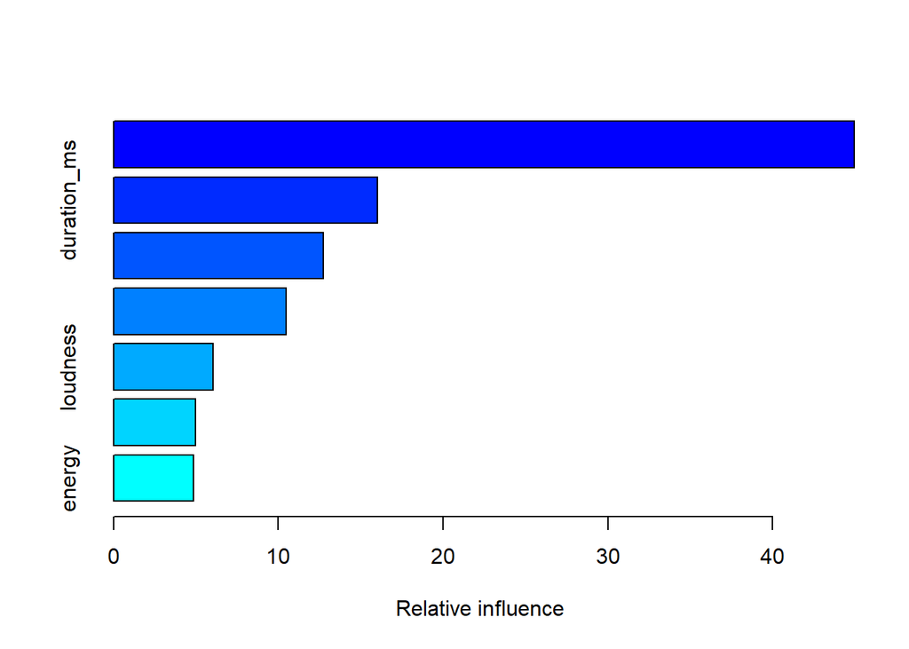

```
##                               var   rel.inf
## tempo                       tempo 44.948843
## duration_ms           duration_ms 16.014185
## instrumentalness instrumentalness 12.744217
## danceability         danceability 10.465360
## loudness                 loudness  6.022125
## valence                   valence  4.973661
## energy                     energy  4.831608
```

```r
library(gbm)
train_x <- top_features_traindata[, setdiff(names(top_features_traindata), "genre")]
train_y <- top_features_traindata$genre


gbm_model <- gbm(
  formula = genre ~ .,
  distribution = "multinomial",
  data = top_features_traindata,
  n.trees = 100,
  interaction.depth = 3,
  shrinkage = 0.1,
  cv.folds = 5,
  n.minobsinnode = 10,
  verbose = TRUE
)
summary(gbm_model)
```

We can summarize the results as follows-

Focussing on prediction accuracy of the GBM model-

```r
train_pred <- predict(gbm_model, top_features_traindata, n.trees = 100, type = "response")

train_pred_class <- colnames(train_pred)[apply(train_pred, 1, which.max)]

test_pred <- predict(gbm_model, top_features_testdata, n.trees = 100, type = "response")
test_pred_class <- colnames(test_pred)[apply(test_pred, 1, which.max)]


train_accuracy <- confusionMatrix(as.factor(train_pred_class), as.factor(top_features_traindata$genre))
print(train_accuracy$overall['Accuracy'])
```

```
##  Accuracy
## 0.6847595
```

```r
test_accuracy <- confusionMatrix(as.factor(test_pred_class), as.factor(top_features_testdata$genre))
print(test_accuracy$overall['Accuracy'])
```

```
##  Accuracy
## 0.6619785
```

The prediction results of the GBM model are-

Performance Considerations: While the accuracies are decent, they also indicate that there’s room for improvement. This could be achieved through more feature engineering, hyperparameter tuning, or even using more advanced models if necessary. The complexity of the ‘genre’ classification task could mean that there are nuances in the data that are not fully captured by the current features.

Model Complexity and Training Time: Gradient Boosting models, especially with multiple iterations and deeper trees, can be computationally intensive. The slight increase in accuracy over the RandomForest model should be weighed against the computational resources and time required for training.

Overall, the Gradient Boosting model appears to be a slightly better choice for this classification task compared to the RandomForest, with a better balance between bias and variance, as evidenced by its training and test accuracies.

Finally, we have the XG Boost Model-

```r
library(xgboost)
top_features_traindata$genre <- as.numeric(as.factor(top_features_traindata$genre)) - 1
top_features_testdata$genre <- as.numeric(as.factor(top_features_testdata$genre)) - 1


dtrain <- xgb.DMatrix(data = as.matrix(top_features_traindata[, -which(names(top_features_traindata) == "genre")]), label = top_features_traindata$genre)
dtest <- xgb.DMatrix(data = as.matrix(top_features_testdata[, -which(names(test_data) == "genre")]), label = top_features_testdata$genre)


params <- list(
  booster = "gbtree",
  objective = "multi:softprob",
  num_class = length(unique(top_features_traindata$genre)),
  eval_metric = "mlogloss"
)

nrounds <- 100

xgb_model <- xgb.train(params = params, data = dtrain, nrounds = nrounds)
```

```r
test_pred_prob <- predict(xgb_model, dtest)
num_class <- length(unique(top_features_traindata$genre))
test_pred <- matrix(test_pred_prob, ncol = num_class, byrow = TRUE)
test_pred_labels <- max.col(test_pred) - 1


levels_genres <- levels(as.factor(top_features_traindata$genre))
test_pred_factor <- factor(test_pred_labels, levels = 0:(num_class - 1), labels = levels_genres)

conf_matrix <- confusionMatrix(test_pred_factor, as.factor(top_features_testdata$genre))
accuracy <- conf_matrix$overall['Accuracy']
print(accuracy)
```

```
##  Accuracy
## 0.6606784
```

The model’s performance is evaluated using a confusion matrix, and the overall accuracy is derived. Notably, the accuracy achieved on the testing set is approximately 66.07%, providing insights into the model’s effectiveness in classifying music genres based on the specified features.

Model Characteristics:

Ensemble Methods (RandomForest, Gradient Boosting, XGBoost): These models performed similarly and better than KNN. This is likely due to their ability to handle complex relationships in data by building multiple decision trees (RandomForest) or sequentially improving predictions (Gradient Boosting and XGBoost). KNN: Being a simpler, distance-based algorithm, KNN might struggle with the high-dimensional space or complex patterns in the data. Its lower performance suggests that the genre classification task may be too complex for KNN to capture effectively with the given features.

Feature Importance and Complexity:

The close performance of RandomForest, Gradient Boosting, and XGBoost suggests that the top features selected are quite informative for the genre classification task. However, the fact that none of the models achieved very high accuracy indicates that genre classification might be inherently complex, with nuances not fully captured by these features. KNN’s lower performance could also indicate that the feature space does not have clearly defined boundaries for different genres, which is where KNN generally excels.

# **Conclusion and Future Scope**

In conclusion, our project explored the intricate world of music genres using a mix of data analysis and machine learning. We started by digging into how various musical features like tempo, energy, and speechiness relate to different genres, challenging our assumptions and revealing unique genre-specific traits.

Moving on to machine learning, we tested different models like RandomForest, Gradient Boosting, XGBoost, and KNN to predict music genres. Gradient Boosting turned out to be the most effective, emphasizing the power of combining different models to understand complex patterns in the data. We compared their accuracies and metrics, highlighting the difficulties in classifying genres and the strengths of each algorithm.

Throughout the project, we focused on key features like tempo, duration, danceability, and more, showing their importance in predicting genres. This project not only provided valuable insights into the characteristics and relationships within music genres but also showcased the strengths and limitations of different machine learning models in tackling the complex task of genre prediction. The holistic approach, combining exploratory data analysis and predictive modeling, contributes to a deeper understanding of the diverse and ever-evolving world of music. As music continues to evolve, these insights pave the way for future research, refinement of models, and a more nuanced appreciation of the dynamic interplay between musical features and genres.

Regarding the Future Scope, it is vast and promising, with several avenues for further exploration and improvement. Firstly, expanding the set of musical features or exploring more intricate audio characteristics could enhance the models’ predictive capabilities. Fine-tuning existing models along with considering neural network architectures, may yield improved accuracy. The dataset could be broadened to include a more diverse collection of genres, artists, and styles, offering a more comprehensive understanding of the musical landscape.

Looking ahead, we can make the music experience even better by involving users in the process. If we let users share their preferences, the models can tailor recommendations to individual tastes, making the music journey more enjoyable. Additionally, studying how music genres change over time and differ across cultures could offer fascinating insights. To ensure our models are reliable, we can work with music experts to validate and interpret their predictions. Ultimately, we aim to put these models into action on music platforms, providing users with more accurate and personalized genre suggestions. This way, we contribute to the exciting and always changing world of discovering new music.

# **References**

[1] ANDRII SAMOSHYN, Dataset of songs in Spotify,Kaggle Retrieved on Oct 18,2023; https://www.kaggle.com/datasets/mrmorj/dataset-of-songs-in-spotify

[2] Prasad Patil, Published in Towards Data Science (Mar 23,2018), Retrieved on Oct 31,2023; https://towardsdatascience.com/exploratory-data-analysis-8fc1cb20fd15

[3] What is exploratory data analysis?, IBM, Retrieved on Oct 31,2023; https://www.ibm.com/topics/exploratory-data-analysis

[4] Codecademy Team, Exploratory Data Analysis: Data Visualization, Retrieved on Oct 31,2023; https://www.codecademy.com/article/eda-data-visualization

[5] PCA, Zakaria Jaadi,A Step-by-Step Explanation of Principal Component Analysis (PCA), Retrieved on Dec 15,2023 https://builtin.com/data-science/step-step-explanation-principal-component-analysis

[6] Understand Random Forest Algorithms, Sruthi E R, Retrieved on Dec 15,2023; https://www.analyticsvidhya.com/blog/2021/06/understanding-random-forest/

[7] Gradient Boosting in ML, Retrieved on Dec 15,2023; https://www.geeksforgeeks.org/ml-gradient-boosting/

[8] XGBoost, Retrieved on Dec 15,2023; https://www.nvidia.com/en-us/glossary/data-science/xgboost/

[9] K-Nearest Neighbors Algorithm, Retrieved on Dec 15,2023; https://www.ibm.com/topics/knn